# **Which Beauty Products do Customers Often Buy Together?**

*Mining Association Rules for a Beauty Products Shop*

Independent Data Analysis Project

Author

Affiliation

John Karuitha

Karatina University, Kenya

Published

January 8, 2023

# 1 **Background**

In this mini-project, I explore association rules using data from a beauty products shop.

> Association rule learning is a rule-based machine learning method for discovering interesting relations between variables in large databases. It is intended to identify strong rules discovered in databases using some measures of interestingness.In any given transaction with a variety of items, association rules are meant to discover the rules that determine how or why certain items are connected (Kotsiantis and Kanellopoulos 2006).

The questions that I explore in this analysis are;

- Which beauty products have the highest demand? (See section 3)
- Which combinations of beauty products are often purchased together? (See section 4)
- How best can the owner of this beauty shop utilize this analysis? (See section 6)

**Read More of my Work**

Please visit my rpubs site to see more data projects. Alternatively, copy and paste the link https://www.rpubs.com/Karuitha into your browser.

My data visualizations projects are available in my [Tableau Public profile page](https://public.tableau.com/app/profile/john.karuitha) or copy and paste the link https://public.tableau.com/app/profile/john.karuitha.

My Shiny web apps are available on this [site](https://karuitha.shinyapps.io/). You can copy-paste this web address instead https://karuitha.shinyapps.io/.

**Tools Utilized & Skills Applied**

R (R Core Team 2022), arules, arulesViz, Quarto, Data Science, Association Rules Mining.

Note, however, many rules generated using this association rules mining maybe trivial. It would require domain expertise sift through the output to spot actionable rules.

# 2 **Data**

The file Cosmetics.csv contains 1000 records of transactions of cosmetics sales in a beauty shop (1: purchased; 0: no purchased). Each transaction is tied to an invoice so that the data shows the basket of items that each consumer bought on a given date.

```r
## read in the data
cosmetics <- read_csv("Cosmetics.csv") %>%
    clean_names() %>%
    mutate(invoice_number = paste0("c", 1:nrow(.))) %>%
    pivot_longer(cols = -invoice_number,
                 names_to = "item",
                 values_to = "bought") %>%
    filter(bought == 1) %>%
    mutate(invoice_number = factor(invoice_number)) %>%
    group_by(invoice_number) %>%
    filter(!duplicated(item)) %>%
    ungroup()

head(cosmetics, 10) %>% formatting_function(caption = "A Peek into the Data")
```

A Peek into the Data

| invoice_number | item | bought |
| --- | --- | --- |
| c1 | blush | 1 |
| c1 | nail_polish | 1 |
| c1 | brushes | 1 |
| c1 | concealer | 1 |
| c1 | bronzer | 1 |
| c1 | lip_liner | 1 |
| c1 | mascara | 1 |
| c1 | eyeliner | 1 |
| c2 | nail_polish | 1 |
| c2 | concealer | 1 |

# 3 **Most Popular Items**

After reading in the data and converting the data into a transactions object, I build an item frequency plot. The plot shows the most popular items in all transactions contained in the data. The 2 most popular items are `foundation` and `lip gross`.

```r
## Split the data by invoice number
my_bundles <- split(cosmetics$item, cosmetics$invoice_number)
my_bundles <- sapply(my_bundles, unique)
```

```r
trans <- as(my_bundles, "transactions")
summary(trans)
```

```
transactions as itemMatrix in sparse format with
 957 rows (elements/itemsets/transactions) and
 14 columns (items) and a density of 0.33

most frequent items:
foundation  lip_gloss   eyeliner  concealer eye_shadow    (Other)
       536        490        457        442        381       2080

element (itemset/transaction) length distribution:
sizes
  1   2   3   4   5   6   7   8   9  10  11  12  13
 67 116 166 158 156 107  79  53  17  18  16   3   1

   Min. 1st Qu.  Median    Mean 3rd Qu.    Max.
    1.0     3.0     4.0     4.6     6.0    13.0

includes extended item information - examples:
   labels
1     bag
2   blush
3 bronzer

includes extended transaction information - examples:
  transactionID
1            c1
2           c10
3          c100
```

```r
itemFrequency(trans)
```

```
            bag           blush         bronzer         brushes       concealer
          0.056           0.379           0.292           0.156           0.462
     eye_shadow eyebrow_pencils        eyeliner      foundation       lip_gloss
          0.398           0.044           0.478           0.560           0.512
      lip_liner        lipstick         mascara     nail_polish
          0.245           0.336           0.373           0.293
```

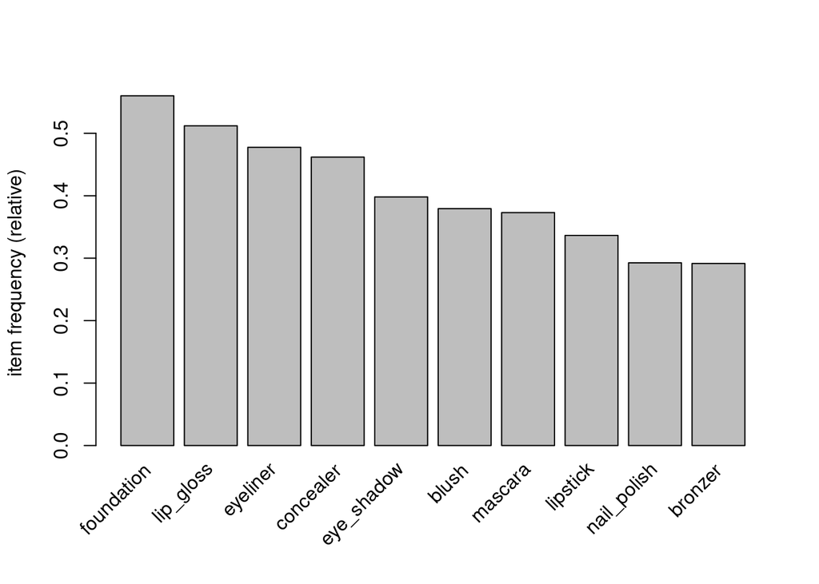

Most Frequently Bought Items

```r
itemFrequencyPlot(trans, topN = 10)
```